# DS4P: Visualizing Relationships Between Variables

DS4P: Visualizing Relationships Between Variables Lecture 9

## Learning Objectives

1. Create and interpret boxplots to compare distributions across groups
2. Master scatterplots for examining relationships between continuous variables
3. Use `facet_wrap()` to create small multiples for comparative analysis
4. Combine multiple visual elements (color, shape, faceting) to display 3-4 variables simultaneously
5. Choose the appropriate visualization for different types of variable relationships

## What Is This For?

In the previous session, we learned how to visualize single variables - the distribution of ages, the frequency of categories, the spread of continuous data. But in real research, we rarely care about variables in isolation. We want to know: Do wealthy countries have higher life expectancies? Does education affect political participation? Are movie critics harsher than general audiences?

These questions require us to visualize *relationships* between variables. Today, we’ll learn three powerful techniques:

1. **Boxplots for group comparisons** - When you have a continuous variable and want to compare it across categories
2. **Scatterplots for continuous relationships** - When both variables are continuous and you want to see patterns
3. **Faceting for deeper insights** - When you need to examine relationships separately for different subgroups

By the end of this session, you’ll be able to create visualizations that reveal complex patterns in your data - the kind of insights that tables of numbers simply can’t provide.

## Comparing Groups with Boxplots

### When to Use Boxplots

Boxplots excel when you want to compare a continuous variable across different categories. They’re particularly useful because they show:

- The median (center line)
- The interquartile range (the box)
- The full spread (whiskers)
- Outliers (individual points)

All in a compact, easy-to-compare format.

### Congressional Age Example

Let’s examine age patterns in the U.S. Congress using the FiveThirtyEight dataset. This data contains information about every member of Congress from 1947 to 2013.

```r
# Load required packages
library(fivethirtyeight)
library(ggplot2)
library(dplyr)

# Load the congressional age data
data("congress_age")

# Examine the structure
glimpse(congress_age)
```

```
## Rows: 18,635
## Columns: 13
## $ congress   <int> 80, 80, 80, 80, 80, 80, 80, 80, 80, 80, 80, 80, 80, 80, 80,…
## $ chamber    <chr> "house", "house", "house", "house", "house", "house", "hous…
## $ bioguide   <chr> "M000112", "D000448", "S000001", "E000023", "L000296", "G00…
## $ firstname  <chr> "Joseph", "Robert", "Adolph", "Charles", "William", "James"…
## $ middlename <chr> "Jefferson", "Lee", "Joachim", "Aubrey", NA, "A.", "Joseph"…
## $ lastname   <chr> "Mansfield", "Doughton", "Sabath", "Eaton", "Lewis", "Galla…
## $ suffix     <chr> NA, NA, NA, NA, NA, NA, NA, NA, NA, NA, NA, NA, NA, NA, NA,…
## $ birthday   <date> 1861-02-09, 1863-11-07, 1866-04-04, 1868-03-29, 1868-09-22…
## $ state      <chr> "TX", "NC", "IL", "NJ", "KY", "PA", "CA", "NY", "WI", "MA",…
## $ party      <chr> "D", "D", "D", "R", "R", "R", "R", "D", "R", "R", "D", "R",…
## $ incumbent  <lgl> TRUE, TRUE, TRUE, TRUE, FALSE, FALSE, TRUE, TRUE, TRUE, TRU…
## $ termstart  <date> 1947-01-03, 1947-01-03, 1947-01-03, 1947-01-03, 1947-01-03…
## $ age        <dbl> 85.9, 83.2, 80.7, 78.8, 78.3, 78.0, 77.9, 76.8, 76.0, 75.8,…
```

First, let’s clean up the chamber variable to have proper capitalization:

```r
# Recode chamber names for better display
congress_age <- congress_age %>%
  mutate(chamber = recode(chamber,
    "house" = "House",
    "senate" = "Senate"
  ))

# Check our recoding
table(congress_age$chamber)
```

```
##
##  House Senate
##  15083   3552
```

### Creating a Basic Boxplot

Let’s compare ages between the House and Senate:

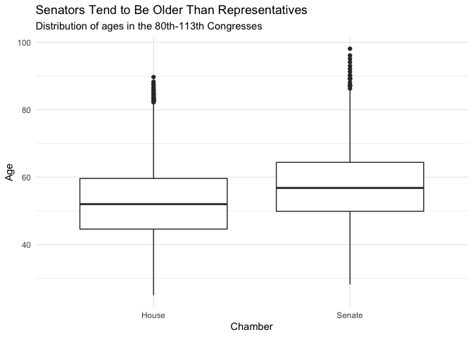

```r
# Basic boxplot
ggplot(data = congress_age) +
  geom_boxplot(aes(x = chamber, y = age)) +
  labs(
    x = "Chamber",
    y = "Age",
    title = "Senators Tend to Be Older Than Representatives",
    subtitle = "Distribution of ages in the 80th-113th Congresses"
  ) +
  theme_minimal()
```

Let’s break down this code:

- `geom_boxplot()` creates the boxplot geometry
- Inside `aes()` (aesthetic mapping), we specify:
  - `x = chamber`: The categorical variable for groups (House vs Senate)
  - `y = age`: The continuous variable we’re comparing
- The `aes()` function is crucial - it tells ggplot which variables in your data should control which visual properties

### Adding a Third Variable with Color

Now let’s add incumbency status to see if the age difference is driven by new members or veterans:

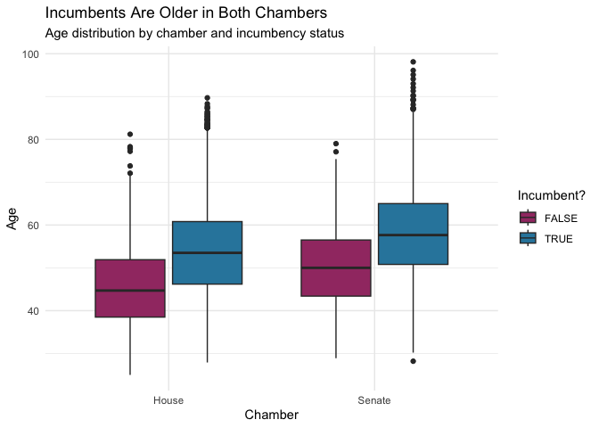

```r
# Boxplot with color for incumbency
ggplot(data = congress_age) +
  geom_boxplot(aes(x = chamber, y = age, fill = incumbent)) +
  labs(
    x = "Chamber",
    y = "Age",
    title = "Incumbents Are Older in Both Chambers",
    subtitle = "Age distribution by chamber and incumbency status",
    fill = "Incumbent?"
  ) +
  theme_minimal() +
  scale_fill_manual(values = c("TRUE" = "#2E86AB", "FALSE" = "#A23B72"))
```

Here’s what changed:

- We added `fill = incumbent` inside `aes()`
  - This creates a **mapping** between the incumbent variable and the fill color
  - ggplot automatically assigns different colors to TRUE/FALSE
  - Because it’s inside `aes()`, ggplot knows to create separate boxes for each value
- `scale_fill_manual()` lets us customize the colors:
  - We specify exact colors for TRUE (blue) and FALSE (pink)
  - Without this, ggplot would use default colors

**Key concept**: When you put an argument inside `aes()`, you’re creating a mapping between data and visual properties. When it’s outside `aes()`, you’re setting a fixed property for all data points.

The side-by-side boxes reveal that:

- Incumbents are older than non-incumbents in both chambers
- The age gap between chambers exists for both groups
- Non-incumbent senators are still older than non-incumbent representatives

### Using Facets Instead of Colors

Sometimes, faceting provides clearer comparisons than colors:

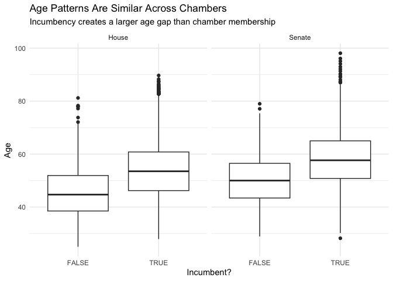

```r
# Using facets for chamber comparison
ggplot(data = congress_age) +
  geom_boxplot(aes(x = incumbent, y = age)) +
  facet_wrap(~chamber) +
  labs(
    x = "Incumbent?",
    y = "Age",
    title = "Age Patterns Are Similar Across Chambers",
    subtitle = "Incumbency creates a larger age gap than chamber membership"
  ) +
  theme_minimal()
```

Notice the changes:

- We switched what’s on the x-axis: now `x = incumbent`
- We removed the `fill` aesthetic - back to single-colored boxes
- `facet_wrap(~chamber)` creates separate panels:
  - The `~` (tilde) is R’s formula notation
  - It means “create facets by the chamber variable”
  - Each unique value of chamber gets its own panel

Faceting makes it easier to focus on the incumbency comparison within each chamber. You can directly compare the TRUE vs FALSE boxes without the visual interference of different colors.

### Visualizing Change Over Time

Let’s push our visualization further by examining how these patterns have changed over the decades:

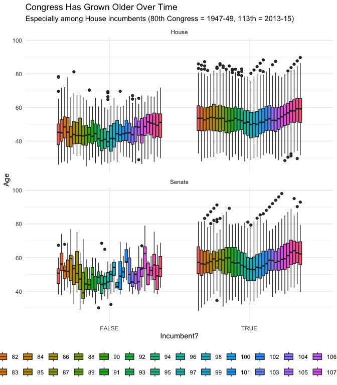

```r
# Convert congress number to factor for discrete colors
congress_age$congress <- as.factor(congress_age$congress)

# Create a complex visualization
ggplot(data = congress_age) +
  geom_boxplot(aes(x = incumbent, y = age, fill = congress)) +
  facet_wrap(~chamber, ncol = 1) +
  labs(
    x = "Incumbent?",
    y = "Age",
    fill = "Congress",
    title = "Congress Has Grown Older Over Time",
    subtitle = "Especially among House incumbents (80th Congress = 1947-49, 113th = 2013-15)"
  ) +
  theme_minimal() +
  theme(legend.position = "bottom") +
  guides(fill = guide_legend(nrow = 2))
```

This code combines everything we’ve learned:

- `fill = congress` inside `aes()` assigns a different color to each Congress
- `facet_wrap(~chamber, ncol = 1)` creates one column of facets:
  - `ncol = 1` stacks the panels vertically
  - Without this, ggplot would arrange them side-by-side
- `theme(legend.position = "bottom")` moves the legend below the plot
- `guides(fill = guide_legend(nrow = 2))` arranges the legend in 2 rows
  - This prevents the legend from being too wide

**Important**: We converted `congress` to a factor first. This tells ggplot to treat each Congress as a discrete category rather than a continuous number, giving us distinct colors instead of a gradient.

## Scatterplots for Continuous Relationships

### When Two Variables Are Both Continuous

Boxplots work great when one variable is categorical. But what if both variables are continuous? Enter the scatterplot - the workhorse of data exploration.

### Movie Ratings Example

Let’s explore how professional critics and general audiences rate movies differently. We’ll use a dataset of 651 randomly sampled movies:

```r
# Load the movies data
MovieData <- read.csv("https://www.dropbox.com/scl/fi/v2ldpanyvhy2nb18vy20r/movies.csv?rlkey=g0tfkjuv3y4tbgsgvfx9c95sk&dl=1")

# Examine the structure
str(MovieData)
```

```
## 'data.frame':    651 obs. of  32 variables:
##  $ title           : chr  "Filly Brown" "The Dish" "Waiting for Guffman" "The Age of Innocence" ...
##  $ title_type      : chr  "Feature Film" "Feature Film" "Feature Film" "Feature Film" ...
##  $ genre           : chr  "Drama" "Drama" "Comedy" "Drama" ...
##  $ runtime         : int  80 101 84 139 90 78 142 93 88 119 ...
##  $ mpaa_rating     : chr  "R" "PG-13" "R" "PG" ...
##  $ studio          : chr  "Indomina Media Inc." "Warner Bros. Pictures" "Sony Pictures Classics" "Columbia Pictures" ...
##  $ thtr_rel_year   : int  2013 2001 1996 1993 2004 2009 1986 1996 2012 2012 ...
##  $ thtr_rel_month  : int  4 3 8 10 9 1 1 11 9 3 ...
##  $ thtr_rel_day    : int  19 14 21 1 10 15 1 8 7 2 ...
##  $ dvd_rel_year    : int  2013 2001 2001 2001 2005 2010 2003 2004 2013 2012 ...
##  $ dvd_rel_month   : int  7 8 8 11 4 4 2 3 1 8 ...
##  $ dvd_rel_day     : int  30 28 21 6 19 20 18 2 21 14 ...
##  $ imdb_rating     : num  5.5 7.3 7.6 7.2 5.1 7.8 7.2 5.5 7.5 6.6 ...
##  $ imdb_num_votes  : int  899 12285 22381 35096 2386 333 5016 2272 880 12496 ...
```

[output cut: 18 more lines]

```r
# Focus on key variables
MovieData %>%
  select(title, critics_score, audience_score, genre, mpaa_rating) %>%
  head()
```

```
##                  title critics_score audience_score       genre mpaa_rating
## 1          Filly Brown            45             73       Drama           R
## 2             The Dish            96             81       Drama       PG-13
## 3  Waiting for Guffman            91             91      Comedy           R
## 4 The Age of Innocence            80             76       Drama          PG
## 5          Malevolence            33             27      Horror           R
## 6          Old Partner            91             86 Documentary     Unrated
```

### Creating a Basic Scatterplot

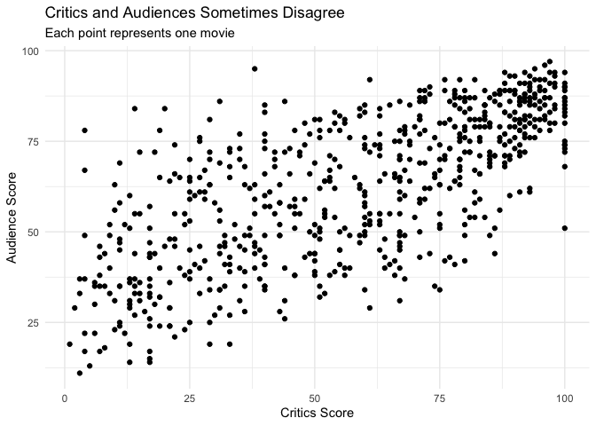

```r
# Basic scatterplot
ggplot(data = MovieData) +
  geom_point(aes(x = critics_score, y = audience_score)) +
  labs(
    x = "Critics Score",
    y = "Audience Score",
    title = "Critics and Audiences Sometimes Disagree",
    subtitle = "Each point represents one movie"
  ) +
  theme_minimal()
```

Here’s how scatterplots differ from boxplots:

- `geom_point()` creates points instead of boxes
- Both `x` and `y` in `aes()` are now continuous variables
- Each observation gets its own point (unlike boxplots which summarize groups)

The pattern shows:

- A general positive relationship (critics and audiences often agree)
- Considerable scatter (they don’t always agree)
- Some movies loved by audiences but not critics (upper left)
- Some movies loved by critics but not audiences (lower right)

### Dealing with Overplotting

When many points overlap, we lose information. Two solutions:

**Solution 1: Jittering**

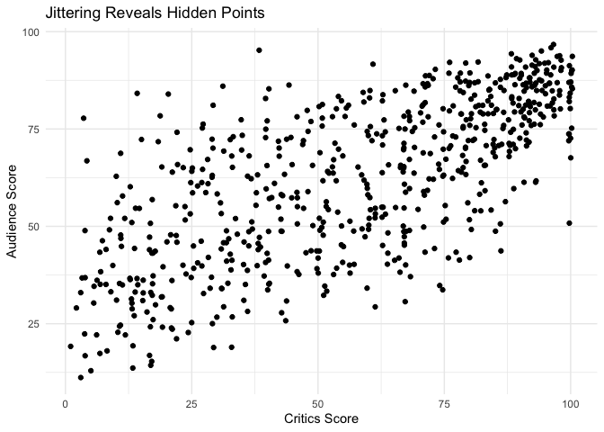

```r
# Add small random noise to separate overlapping points
ggplot(data = MovieData) +
  geom_point(aes(x = critics_score, y = audience_score),
             position = "jitter") +
  labs(
    x = "Critics Score",
    y = "Audience Score",
    title = "Jittering Reveals Hidden Points"
  ) +
  theme_minimal()
```

Note that `position = "jitter"` is **outside** the `aes()` function:

- This is a fixed setting that applies to all points
- It adds small random noise to x and y coordinates
- The amount of jitter is automatically determined by ggplot

**Solution 2: Transparency**

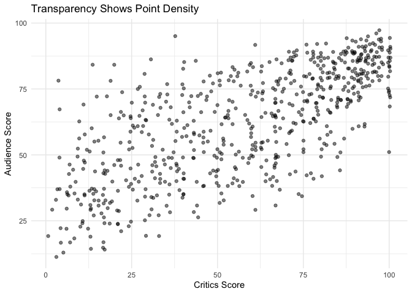

```r
# Make points semi-transparent
ggplot(data = MovieData) +
  geom_point(aes(x = critics_score, y = audience_score),
             position = "jitter",
             alpha = 0.5) +  # 50% transparency
  labs(
    x = "Critics Score",
    y = "Audience Score",
    title = "Transparency Shows Point Density"
  ) +
  theme_minimal()
```

Here we added `alpha = 0.5`:

- Also outside `aes()` because we want all points to have the same transparency
- Values range from 0 (invisible) to 1 (solid)
- Where points overlap, the color appears darker
- This helps reveal density patterns